# R Notebook

```r
library(randomforest)
```

```
Error in library(randomforest) :
  aucun package nommé ‘randomforest’ n'est trouvé
```

# Notes générales

- Training dataset : prédiction du cours du bitcoin entre le 1er mai 2017 et le 1er mai 2018
- Test dataset : prédiction du cours du bitcoin entre le 1er mai 2018 et le 31 juillet 2018

# Chargement des données

## Bitcoin

```r
bitcoin.prices = read.csv('./data/btc_quote.csv') %>% select(-X)
bitcoin.prices$Date = ymd(bitcoin.prices$Date)
colnames(bitcoin.prices) = c('date', 'open', 'high', 'low', 'close', 'volume', 'market.cap', 'price')
```

Ajout du prix de cloture au jour J-1 et J-2:

```r
bitcoin.prices$close.D1 = c(NA, bitcoin.prices$close[c(1:(nrow(bitcoin.prices) - 1))])
bitcoin.prices$close.movavg = bitcoin.prices$close - movavg(bitcoin.prices$close, 7)
```

```
la condition a une longueur > 1 et seul le premier élément est utilisé
```

```r
bitcoin.prices$close.D2 = c(NA, bitcoin.prices$close.D1[c(1:(nrow(bitcoin.prices) - 1))])
```

Ajout de la variable Up / Down :

```r
bitcoin.prices$trend = (bitcoin.prices$close - bitcoin.prices$close.D1) > 0
bitcoin.prices$trend = factor(bitcoin.prices$trend, levels = c(FALSE, TRUE), labels = c("Down", "Up"))
bitcoin.prices$trend.D1 = c(NA, bitcoin.prices$trend[c(1:(nrow(bitcoin.prices) - 1))])
bitcoin.prices$trend.D1 = factor(bitcoin.prices$trend.D1, levels = c(1, 2), labels = c("Up", "Down"))
bitcoin.prices$trend.D2 = c(NA, bitcoin.prices$trend.D1[c(1:(nrow(bitcoin.prices) - 1))])
bitcoin.prices$trend.D2 = factor(bitcoin.prices$trend.D2, levels = c(1, 2), labels = c("Up", "Down"))
```

```r
bitcoin.prices = bitcoin.prices %>% select(c(date, close.D1, close.D2, trend.D1, trend.D2, close, trend))
```

On fait enfin un filtre sur la date pour ne garder que ce qui nous intéresse.

```r
bitcoin.prices = bitcoin.prices %>% filter(date >= ymd('2017-05-01') & date <= ymd('2018-07-31'))
```

## Données de scraping

Ces données ont été générées à partir du dataset `NLP_Crypto_Dataset`, et traitées sur Jupyter (notebook `NLP_new_data`).

```r
NLP_data = read.csv('./data/NLP_grouped_data.csv')
```

On ajoute la différence entre le nombre de posts et sa moyenne glissante sur sept jours:

```r
NLP_data$post.movavg = NLP_data$post - movavg(NLP_data$post, 7)
```

```
la condition a une longueur > 1 et seul le premier élément est utilisé
```

On dédouble toutes les colonnes pour avoir leur valeur à J-1 :

```r
column_names = colnames(NLP_data)
for(column in colnames(NLP_data)){

  NLP_data = data.frame(NLP_data,
                        c(NA, NLP_data[[column]][c(1:(nrow(NLP_data)) - 1)]))

}
# Change column names to be a bit cleaner
colnames(NLP_data) = c(column_names, paste0(column_names, '.D1'))
# Remove date.D1 since it does not make any sense
NLP_data = NLP_data %>% dplyr::select(-date.D1)
```

De même, on fait un filtre sur les dates pour ne conserver que la période qui nous intéresse.

```r
NLP_data$date = ymd(NLP_data$date)
NLP_data = NLP_data %>% filter(date >= ymd('2017-05-01') & date <= ymd('2018-07-31'))
```

## Données Google Trends

Ces données ont été obtenues grâce au notebook Jupyter `GoogleTrendsGenerator`.

```r
GT_data = read.csv('./data/merged_trends.csv')
GT_data$date = ymd(GT_data$date)
colnames(GT_data) = c("date", paste0('gt.', colnames(GT_data)[2:ncol(GT_data)]))
GT_data
```

| date | gt.bitcoin | gt.btc | gt.cryptocurrency | gt.hodl | gt.blockchain |
| --- | --- | --- | --- | --- | --- |
| 2017-05-01 | 4 | 9 | 2 | 1 | 15 |
| 2017-05-02 | 4 | 10 | 1 | 1 | 19 |
| 2017-05-03 | 4 | 9 | 1 | 1 | 18 |
| 2017-05-04 | 5 | 12 | 2 | 1 | 20 |
| 2017-05-05 | 5 | 11 | 3 | 2 | 19 |
| 2017-05-06 | 4 | 10 | 2 | 0 | 12 |
| 2017-05-07 | 4 | 9 | 2 | 1 | 14 |
| 2017-05-08 | 5 | 11 | 3 | 2 | 17 |
| 2017-05-09 | 6 | 13 | 3 | 1 | 20 |
| 2017-05-10 | 6 | 12 | 3 | 2 | 20 |

[output cut: 447 more lines]

## Tout réunir ensemble

```r
full_data = inner_join(NLP_data, GT_data)
full_data = inner_join(full_data, bitcoin.prices)
full_data
```

| date | polarity | log_merit | post | polarity_and_log_merit | post.movavg | polarity.D1 | log_merit.D1 | post.D1 | polarity_and_log_merit.D1 | post.movavg.D1 | gt.bitcoin | gt.btc | gt.cryptocurrency | gt.hodl | gt.blockchain | close.D1 | close.D2 | trend.D1 | trend.D2 | close | trend |
| --- | --- | --- | --- | --- | --- | --- | --- | --- | --- | --- | --- | --- | --- | --- | --- | --- | --- | --- | --- | --- | --- |
| 2017-05-01 | 0.13658172 | 5.973724 | 675 | 0.8015783 | 3.0000000 | 0.11463268 | 6.013855 | 667 | 0.6825033 | -35.7142857 | 4 | 9 | 2 | 1 | 15 | 1347.89 | 1321.79 | Down | Down | 1421.60 | Up |
| 2017-05-02 | 0.11889976 | 5.838863 | 691 | 0.6793545 | 15.0000000 | 0.13658172 | 5.973724 | 675 | 0.8015783 | 3.0000000 | 4 | 10 | 1 | 1 | 19 | 1421.60 | 1347.89 | Down | Down | 1452.82 | Up |
| 2017-05-03 | 0.15324263 | 5.759635 | 708 | 0.8682710 | 40.0000000 | 0.11889976 | 5.838863 | 691 | 0.6793545 | 15.0000000 | 4 | 9 | 1 | 1 | 18 | 1452.82 | 1421.60 | Down | Down | 1490.09 | Up |
| 2017-05-04 | 0.12990725 | 6.027046 | 672 | 0.7705107 | 9.0000000 | 0.15324263 | 5.759635 | 708 | 0.8682710 | 40.0000000 | 5 | 12 | 2 | 1 | 20 | 1490.09 | 1452.82 | Down | Down | 1537.67 | Up |
| 2017-05-05 | 0.14646307 | 5.705774 | 950 | 0.8269913 | 233.8571429 | 0.12990725 | 6.027046 | 672 | 0.7705107 | 9.0000000 | 5 | 11 | 3 | 2 | 19 | 1537.67 | 1490.09 | Down | Down | 1555.45 | Up |
| 2017-05-06 | 0.12949446 | 5.930459 | 682 | 0.7754442 | -38.7142857 | 0.14646307 | 5.705774 | 950 | 0.8269913 | 233.8571429 | 4 | 10 | 2 | 0 | 12 | 1555.45 | 1537.67 | Down | Down | 1578.80 | Up |
| 2017-05-07 | 0.14520167 | 5.818141 | 655 | 0.8554904 | -64.0000000 | 0.12949446 | 5.930459 | 682 | 0.7754442 | -38.7142857 | 4 | 9 | 2 | 1 | 14 | 1578.80 | 1555.45 | Down | Down | 1596.71 | Up |
| 2017-05-08 | 0.17052337 | 5.734340 | 711 | 0.9531864 | -13.1428571 | 0.14520167 | 5.818141 | 655 | 0.8554904 | -64.0000000 | 5 | 11 | 3 | 2 | 17 | 1596.71 | 1578.80 | Down | Down | 1723.35 | Up |
| 2017-05-09 | 0.16969785 | 5.840582 | 681 | 0.9847823 | -41.7142857 | 0.17052337 | 5.734340 | 711 | 0.9531864 | -13.1428571 | 6 | 13 | 3 | 1 | 20 | 1723.35 | 1596.71 | Down | Down | 1755.36 | Up |
| 2017-05-10 | 0.15146449 | 5.929383 | 788 | 0.8929185 | 53.8571429 | 0.16969785 | 5.840582 | 681 | 0.9847823 | -41.7142857 | 6 | 12 | 3 | 2 | 20 | 1755.36 | 1723.35 | Down | Down | 1787.13 | Up |

[output cut: 447 more lines]

## Enfin : définition des données train et test

```r
scale_data = full_data
scale_data[,-c(1,19,20,22)] = full_data[,-c(1,19,20,22)] %>% scale()
train_data = scale_data %>% filter(date >= ymd('2017/05/01') & date < ymd('2018/05/01'))
test_data = scale_data %>% filter(date >= ymd('2018/05/01') & date <= ymd('2018/07/31'))
```

# Premier modèle : régression logistique

## Avec toutes les variables

```r
full.reg.model = glm(as.formula(paste0("trend ~ ", paste0(colnames(full_data)[-c(21,22)], collapse = " + "))),
                family = "binomial",
                data = train_data)
summary(full.reg.model)
```

```
Call:
glm(formula = as.formula(paste0("trend ~ ", paste0(colnames(full_data)[-c(21,
    22)], collapse = " + "))), family = "binomial", data = train_data)

Deviance Residuals:
    Min       1Q   Median       3Q      Max
-2.4070  -1.1804   0.7801   1.0009   1.6264

Coefficients:
                            Estimate Std. Error z value Pr(>|z|)
(Intercept)               -56.467378 130.591346  -0.432  0.66545
date                        0.003248   0.007461   0.435  0.66332
polarity                    0.255567   0.354895   0.720  0.47145
log_merit                   0.257876   1.443745   0.179  0.85824
post                       -1.544927   2.155693  -0.717  0.47358
polarity_and_log_merit      0.065176   1.112897   0.059  0.95330
post.movavg                 0.577486   0.875624   0.660  0.50957
polarity.D1                -0.108541   0.353256  -0.307  0.75865
log_merit.D1               -0.441456   1.422671  -0.310  0.75633
post.D1                     1.765994   2.207209   0.800  0.42365
polarity_and_log_merit.D1   0.572055   1.097458   0.521  0.60219
post.movavg.D1             -0.520476   0.747430  -0.696  0.48621
gt.bitcoin                 -1.727201   0.752850  -2.294  0.02178 *
gt.btc                      2.765983   0.932230   2.967  0.00301 **
gt.cryptocurrency          -0.061696   0.546594  -0.113  0.91013
gt.hodl                    -1.075592   0.454032  -2.369  0.01784 *
gt.blockchain               0.221291   0.366735   0.603  0.54624
close.D1                   -1.717291   1.167789  -1.471  0.14141
close.D2                    1.182044   1.144344   1.033  0.30163
trend.D1Down               -0.003152   0.290417  -0.011  0.99134
trend.D2Down               -0.312941   0.236833  -1.321  0.18638
---
Signif. codes:  0 ‘***’ 0.001 ‘**’ 0.01 ‘*’ 0.05 ‘.’ 0.1 ‘ ’ 1

(Dispersion parameter for binomial family taken to be 1)

    Null deviance: 497.06  on 364  degrees of freedom
Residual deviance: 465.54  on 344  degrees of freedom
AIC: 507.54

Number of Fisher Scoring iterations: 4
```

### ROC et AUC

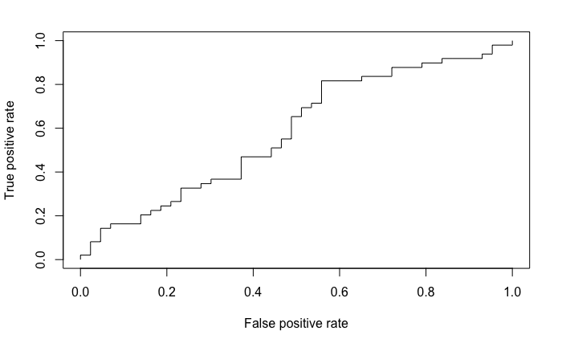

```r
full.reg.predict = predict(full.reg.model, test_data, type = "response")
full.reg.prediction = prediction(full.reg.predict, test_data$trend)
full.reg.perf = performance(full.reg.prediction, measure = "tpr", x.measure = "fpr")
plot(full.reg.perf)
```

```r
reg.auc = performance(full.reg.prediction, measure = "auc")
reg.auc = reg.auc@y.values[[1]]
reg.auc
```

```
[1] 0.5832938
```

### Précision

```r
prediction_vector = rep(NA, nrow(test_data))
prediction_vector[predict(full.reg.model, test_data, type = "response") > 0.5] = "Up"
prediction_vector[is.na(prediction_vector)] = "Down"
print(paste0('Precision on test data: ', sum(prediction_vector == test_data$trend) / nrow(test_data)))
```

```
[1] "Precision on test data: 0.532608695652174"
```

```r
prediction_vector = rep(NA, nrow(train_data))
prediction_vector[predict(full.reg.model, train_data, type = "response") > 0.5] = "Up"
prediction_vector[is.na(prediction_vector)] = "Down"
print(paste0('Precision on train data: ', sum(prediction_vector == train_data$trend) / nrow(train_data)))
```

```
[1] "Precision on train data: 0.66027397260274"
```

## En enlevant quelques variables

```r
colnames(full_data)
```

```
 [1] "date"                      "polarity"                  "log_merit"                 "post"                      "polarity_and_log_merit"
 [6] "post.movavg"               "polarity.D1"               "log_merit.D1"              "post.D1"                   "polarity_and_log_merit.D1"
[11] "post.movavg.D1"            "gt.bitcoin"                "gt.btc"                    "gt.cryptocurrency"         "gt.hodl"
[16] "gt.blockchain"             "close.D1"                  "close.D2"                  "trend.D1"                  "trend.D2"
[21] "close"                     "trend"
```

```r
fewer.reg.model = glm(as.formula(paste0("trend ~ ", paste0(colnames(full_data)[-c(1,3,5,7,8,10,14,16,18,19,21,22)], collapse = " + "))),
                family = "binomial",
                data = train_data)
summary(fewer.reg.model)
```

```
Call:
glm(formula = as.formula(paste0("trend ~ ", paste0(colnames(full_data)[-c(1,
    3, 5, 7, 8, 10, 14, 16, 18, 19, 21, 22)], collapse = " + "))),
    family = "binomial", data = train_data)

Deviance Residuals:
    Min       1Q   Median       3Q      Max
-2.3308  -1.2093   0.7894   1.0174   1.6809

Coefficients:
               Estimate Std. Error z value Pr(>|z|)
(Intercept)      0.3834     0.1773   2.163 0.030544 *
polarity         0.2990     0.1151   2.597 0.009405 **
post            -1.8651     1.9847  -0.940 0.347353
post.movavg      0.7325     0.7886   0.929 0.352970
post.D1          2.1039     1.9918   1.056 0.290845
post.movavg.D1  -0.6272     0.6787  -0.924 0.355455
gt.bitcoin      -1.5631     0.6011  -2.600 0.009309 **
gt.btc           2.6299     0.7635   3.444 0.000572 ***
gt.hodl         -0.9799     0.3087  -3.174 0.001503 **
close.D1        -0.5286     0.2497  -2.117 0.034265 *
trend.D2Down    -0.2784     0.2298  -1.212 0.225605
---
Signif. codes:  0 ‘***’ 0.001 ‘**’ 0.01 ‘*’ 0.05 ‘.’ 0.1 ‘ ’ 1

(Dispersion parameter for binomial family taken to be 1)

    Null deviance: 497.06  on 364  degrees of freedom
Residual deviance: 468.56  on 354  degrees of freedom
AIC: 490.56

Number of Fisher Scoring iterations: 4
```

### ROC et AUC

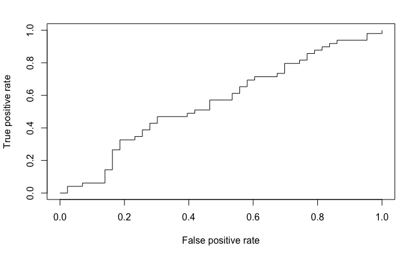

```r
fewer.reg.predict = predict(fewer.reg.model, test_data, type = "response")
fewer.reg.prediction = prediction(fewer.reg.predict, test_data$trend)
fewer.reg.perf = performance(fewer.reg.prediction, measure = "tpr", x.measure = "fpr")
plot(fewer.reg.perf)
```

```r
reg.auc = performance(fewer.reg.prediction, measure = "auc")
reg.auc = reg.auc@y.values[[1]]
reg.auc
```

```
[1] 0.5605126
```

### Précision

```r
prediction_vector = rep(NA, nrow(test_data))
prediction_vector[predict(fewer.reg.model, test_data, type = "response") > 0.5] = "Up"
prediction_vector[is.na(prediction_vector)] = "Down"
print(paste0('Precision on test data: ', sum(prediction_vector == test_data$trend) / nrow(test_data)))
```

```
[1] "Precision on test data: 0.554347826086957"
```

```r
prediction_vector = rep(NA, nrow(train_data))
prediction_vector[predict(fewer.reg.model, train_data, type = "response") > 0.5] = "Up"
prediction_vector[is.na(prediction_vector)] = "Down"
print(paste0('Precision on train data: ', sum(prediction_vector == train_data$trend) / nrow(train_data)))
```

```
[1] "Precision on train data: 0.646575342465753"
```

## En en enlevant encore plus

```r
colnames(full_data)
```

```
 [1] "date"                      "polarity"                  "log_merit"                 "post"                      "polarity_and_log_merit"
 [6] "post.movavg"               "polarity.D1"               "log_merit.D1"              "post.D1"                   "polarity_and_log_merit.D1"
[11] "post.movavg.D1"            "gt.bitcoin"                "gt.btc"                    "gt.cryptocurrency"         "gt.hodl"
[16] "gt.blockchain"             "close.D1"                  "close.D2"                  "trend.D1"                  "trend.D2"
[21] "close"                     "trend"
```

```r
few.reg.model = glm(as.formula(paste0("trend ~ ", paste0(colnames(full_data)[-c(1,3,5,6,7,8,10,11,14,16,18,19,21,22)], collapse = " + "))),
                family = "binomial",
                data = train_data)
summary(few.reg.model)
```

```
Call:
glm(formula = as.formula(paste0("trend ~ ", paste0(colnames(full_data)[-c(1,
    3, 5, 6, 7, 8, 10, 11, 14, 16, 18, 19, 21, 22)], collapse = " + "))),
    family = "binomial", data = train_data)

Deviance Residuals:
    Min       1Q   Median       3Q      Max
-2.3519  -1.2117   0.7942   1.0137   1.6073

Coefficients:
             Estimate Std. Error z value Pr(>|z|)
(Intercept)   0.38182    0.17634   2.165 0.030366 *
polarity      0.29482    0.11472   2.570 0.010168 *
post         -0.03653    0.28671  -0.127 0.898606
post.D1       0.26993    0.28905   0.934 0.350374
gt.bitcoin   -1.57838    0.59486  -2.653 0.007969 **
gt.btc        2.64400    0.75488   3.503 0.000461 ***
gt.hodl      -0.96920    0.30676  -3.159 0.001580 **
close.D1     -0.53296    0.23742  -2.245 0.024784 *
trend.D2Down -0.27886    0.22901  -1.218 0.223348
---
Signif. codes:  0 ‘***’ 0.001 ‘**’ 0.01 ‘*’ 0.05 ‘.’ 0.1 ‘ ’ 1

(Dispersion parameter for binomial family taken to be 1)

    Null deviance: 497.06  on 364  degrees of freedom
Residual deviance: 469.43  on 356  degrees of freedom
AIC: 487.43

Number of Fisher Scoring iterations: 4
```

### ROC et AUC

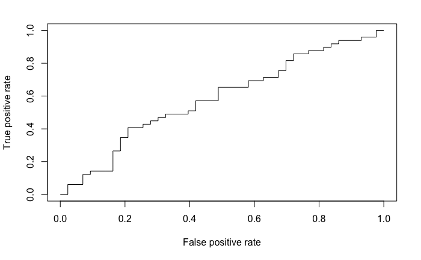

```r
few.reg.predict = predict(few.reg.model, test_data, type = "response")
few.reg.prediction = prediction(few.reg.predict, test_data$trend)
few.reg.perf = performance(few.reg.prediction, measure = "tpr", x.measure = "fpr")
plot(few.reg.perf)
```

```r
reg.auc = performance(few.reg.prediction, measure = "auc")
reg.auc = reg.auc@y.values[[1]]
reg.auc
```

```
[1] 0.5851922
```

### Précision

```r
prediction_vector = rep(NA, nrow(test_data))
prediction_vector[predict(few.reg.model, test_data, type = "response") > 0.5] = "Up"
prediction_vector[is.na(prediction_vector)] = "Down"
print(paste0('Precision on test data: ', sum(prediction_vector == test_data$trend) / nrow(test_data)))
```

```
[1] "Precision on test data: 0.576086956521739"
```

```r
prediction_vector = rep(NA, nrow(train_data))
prediction_vector[predict(few.reg.model, train_data, type = "response") > 0.5] = "Up"
prediction_vector[is.na(prediction_vector)] = "Down"
print(paste0('Precision on train data: ', sum(prediction_vector == train_data$trend) / nrow(train_data)))
```

```
[1] "Precision on train data: 0.632876712328767"
```

Meilleure précision par cette méthode : $57.6\%$.

# Random forest

Malheureusement, les implémentations de Random Forest sur R ne permettent pas de fixer un max_depth. La seule chose à faire est donc de choisir les bonnes variables et d’optimiser le nombre de variables prises par l’arbre à chaque fois.

## Avec toutes les variables

```r
set.seed(0)
full.rf.model = randomForest(as.formula(paste0("trend ~ ", paste0(colnames(full_data)[-c(21,22)], collapse = " + "))),
                             ntree = 5000,
                             data = train_data)
```

```r
print(paste0("Precision on test data: ", sum(predict(full.rf.model, test_data, type = "response") == test_data$trend) / nrow(test_data)))
```

```
[1] "Precision on test data: 0.434782608695652"
```

## Première sélection de variables

On garde la même sélection de variables que sur la deuxième sous-partie de la régression logistique.

```r
set.seed(0)
fewer.rf.model = randomForest(as.formula(paste0("trend ~ ", paste0(colnames(full_data)[-c(1,3,5,7,8,10,14,16,18,19,21,22)], collapse = " + "))),
                             ntree = 5000, mtry = 6, nodesize = 1,
                             data = train_data)
```

```r
print(paste0("Precision on test data: ", sum(predict(fewer.rf.model, test_data, type = "response") == test_data$trend) / nrow(test_data)))
```

```
[1] "Precision on test data: 0.565217391304348"
```

Les résultats sont un peu meilleurs et dépassent le dummy classifier. Le paramètre mtry = 6 (6 variables essayées à chaque arbre) permet de maximiser la précision sur le test dataset.

## Deuxième sélection de variables (plus exigeante)

Ici, on prend la même sélection de variables que sur la troisième sous-partie de la régression logistique.

```r
set.seed(0)
few.rf.model = randomForest(as.formula(paste0("trend ~ ", paste0(colnames(full_data)[-c(1,3,5,6,7,8,10,11,14,16,18,19,21,22)], collapse = " + "))),
                             ntree = 5000, mtry = 4,
                             data = train_data)
```

```r
print(paste0("Precision on test data: ", sum(predict(few.rf.model, test_data, type = "response") == test_data$trend) / nrow(test_data)))
```

```
[1] "Precision on test data: 0.510869565217391"
```

Les résultats sont sensiblement moins bons que dans le cas précédent.